# Case Study 01

Meisam Mansor

June 17, 2019

library(agricolae) library(naniar)

```r
library(ggplot2) # Data visualization
library(readr) # CSV file I/O, e.g. the read_csv function
library(dplyr) # Heavy use of this library
library(tidyr)
library(plyr)
library(ggthemes) # for themes in ggplot
library(knitr)
library(kableExtra) #  for nicer visuals
library(Amelia) # for missing map
library(datasets) # to make region col
library(zoo)
library(agricolae)
library(naniar)
```

```r
# Read in beer and breweries data set using _csv for more tidy output
Beers <- read_csv('Beers.csv', col_types = cols())
Breweries <- read_csv('Breweries.csv', col_types = cols())
```

# 1.How many breweries are present in each state?

```r
BrewPerState <- table(Breweries$State)
BrewPerState
```

```
##
## AK AL AR AZ CA CO CT DC DE FL GA HI IA ID IL IN KS KY LA MA MD ME MI MN MO
##  7  3  2 11 39 47  8  1  2 15  7  4  5  5 18 22  3  4  5 23  7  9 32 12  9
## MS MT NC ND NE NH NJ NM NV NY OH OK OR PA RI SC SD TN TX UT VA VT WA WI WV
##  2  9 19  1  5  3  3  4  2 16 15  6 29 25  5  4  1  3 28  4 16 10 23 20  1
## WY
##  4
```

```r
kable(BrewPerState) #frequency of Breweries in states
```

| Var1 | Freq |
| --- | --- |
| AK | 7 |
| AL | 3 |
| AR | 2 |
| AZ | 11 |
| CA | 39 |
| CO | 47 |
| CT | 8 |
| DC | 1 |
| DE | 2 |
| FL | 15 |
| GA | 7 |
| HI | 4 |
| IA | 5 |
| ID | 5 |
| IL | 18 |
| IN | 22 |
| KS | 3 |
| KY | 4 |
| LA | 5 |
| MA | 23 |
| MD | 7 |
| ME | 9 |
| MI | 32 |
| MN | 12 |
| MO | 9 |
| MS | 2 |
| MT | 9 |
| NC | 19 |
| ND | 1 |
| NE | 5 |
| NH | 3 |
| NJ | 3 |
| NM | 4 |
| NV | 2 |
| NY | 16 |
| OH | 15 |
| OK | 6 |
| OR | 29 |
| PA | 25 |
| RI | 5 |
| SC | 4 |
| SD | 1 |
| TN | 3 |
| TX | 28 |
| UT | 4 |
| VA | 16 |
| VT | 10 |
| WA | 23 |
| WI | 20 |
| WV | 1 |
| WY | 4 |

# 2.Merge beer data with the breweries data. Print the first 6 observations and the last six observations to check the merged file.

##### We can merge them into a single dataset, using full_join by Brewery_id from Beers dataset and Brew_ID from Breweries dataset.

```r
BrewPub <- merge(Beers, Breweries, by.x = "Brewery_id", by.y = "Brew_ID", all = TRUE)

# Change variable names to more meaningful title

BrewPub <- rename(BrewPub, c("Name.x"="Beer","Name.y"="Brewery",
                   "Ounces"="OZ"))
# Used kable library to make document in better visuals
kable(BrewPub %>%
         head()) %>%
         kable_styling("striped", full_width = F)
```

| Brewery_id | Beer | Beer_ID | ABV | IBU | Style | OZ | Brewery | City | State |
| --- | --- | --- | --- | --- | --- | --- | --- | --- | --- |
| 1 | Get Together | 2692 | 0.045 | 50 | American IPA | 16 | NorthGate Brewing | Minneapolis | MN |
| 1 | Maggie’s Leap | 2691 | 0.049 | 26 | Milk / Sweet Stout | 16 | NorthGate Brewing | Minneapolis | MN |
| 1 | Wall’s End | 2690 | 0.048 | 19 | English Brown Ale | 16 | NorthGate Brewing | Minneapolis | MN |
| 1 | Pumpion | 2689 | 0.060 | 38 | Pumpkin Ale | 16 | NorthGate Brewing | Minneapolis | MN |
| 1 | Stronghold | 2688 | 0.060 | 25 | American Porter | 16 | NorthGate Brewing | Minneapolis | MN |
| 1 | Parapet ESB | 2687 | 0.056 | 47 | Extra Special / Strong Bitter (ESB) | 16 | NorthGate Brewing | Minneapolis | MN |

```r
kable(BrewPub %>%
         tail()) %>%
         kable_styling("striped", full_width = F)
```

|  | Brewery_id | Beer | Beer_ID | ABV | IBU | Style | OZ | Brewery | City | State |
| --- | --- | --- | --- | --- | --- | --- | --- | --- | --- | --- |
| 2405 | 556 | Pilsner Ukiah | 98 | 0.055 | NA | German Pilsener | 12 | Ukiah Brewing Company | Ukiah | CA |
| 2406 | 557 | Heinnieweisse Weissebier | 52 | 0.049 | NA | Hefeweizen | 12 | Butternuts Beer and Ale | Garrattsville | NY |
| 2407 | 557 | Snapperhead IPA | 51 | 0.068 | NA | American IPA | 12 | Butternuts Beer and Ale | Garrattsville | NY |
| 2408 | 557 | Moo Thunder Stout | 50 | 0.049 | NA | Milk / Sweet Stout | 12 | Butternuts Beer and Ale | Garrattsville | NY |
| 2409 | 557 | Porkslap Pale Ale | 49 | 0.043 | NA | American Pale Ale (APA) | 12 | Butternuts Beer and Ale | Garrattsville | NY |
| 2410 | 558 | Urban Wilderness Pale Ale | 30 | 0.049 | NA | English Pale Ale | 12 | Sleeping Lady Brewing Company | Anchorage | AK |

# 3. Report the number of NA’s in each column.

#####To do this, we use a function (which returns true if a given value is NA, false otherwise, using is.na) and ‘sapply’ to determine the number of missing values for each column within BrewPub. and also used missmap function from Amelia library to create missing data map.

##### Per results, we find that there are a total of 62 ABV values missing, 1005 IBU values amd 5 Style values missing. No other data is missing.

```r
MissingValues <- sapply(BrewPub,function(MissingValue)sum(is.na(MissingValue)))

# Used kable library to make document more presentable
as.data.frame(MissingValues) %>%
  kable("html") %>%
  kable_styling("striped", full_width = F)
```

|  | MissingValues |
| --- | --- |
| Brewery_id | 0 |
| Beer | 0 |
| Beer_ID | 0 |
| ABV | 62 |
| IBU | 1005 |
| Style | 5 |
| OZ | 0 |
| Brewery | 0 |
| City | 0 |
| State | 0 |

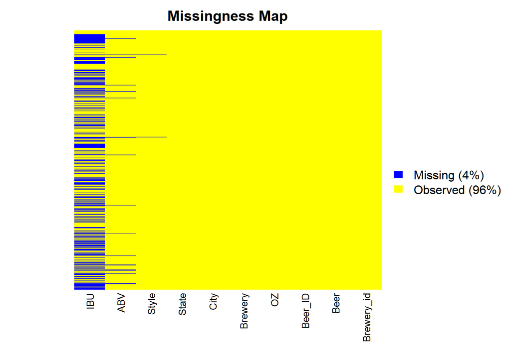

```r
missmap(BrewPub,y.at=c(1),y.labels = c(''),col=c('blue','yellow'))
```

#4.a- Compute the median alcohol content and international bitterness unit for each state. Plot a bar chart to compare.

```r
Alc <- BrewPub %>%
  na.omit()  %>%
group_by(State) %>%
summarise_each(list(median), Median_ABV = ABV) %>%
arrange(Median_ABV)
```

```r
Alc
```

```
## # A tibble: 50 x 2
##    State Median_ABV
##    <chr>      <dbl>
##  1 AR        0.04
##  2 UT        0.04
##  3 NJ        0.046
##  4 NH        0.0465
##  5 KS        0.05
##  6 MO        0.05
##  7 ND        0.05
##  8 SC        0.05
##  9 WI        0.051
## 10 LA        0.051
## # ... with 40 more rows
```

### 4.b- Compute the median international bitterness unit for each state.

```r
Bitter <- BrewPub %>%
  na.omit() %>%
group_by(State) %>%
summarise_each(list(median), Median_IBU = IBU) %>%
arrange(Median_IBU)
```

```r
Bitter
```

```
## # A tibble: 50 x 2
##    State Median_IBU
##    <chr>      <dbl>
##  1 WI          19
##  2 AZ          20
##  3 KS          20
##  4 WY          21
##  5 HI          22.5
##  6 MO          24
##  7 RI          24
##  8 IA          26
##  9 CT          29
## 10 MD          29
## # ... with 40 more rows
```

#### 4. c Plot a bar chart to compare ABV by state

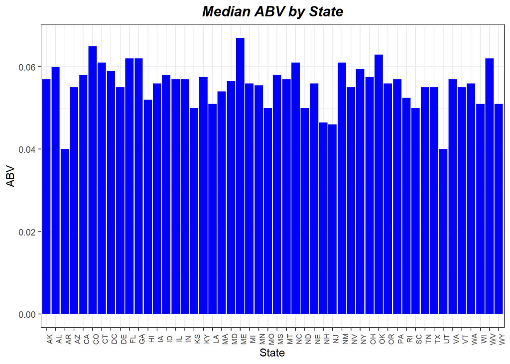

```r
ggplot(data=Alc, aes(x=State, y=Median_ABV)) +
  geom_bar(stat="identity", fill="blue")+
  theme_bw() +
  scale_color_economist()+
  theme(axis.text.x=element_text(size=rel(0.8), angle=90),plot.title = element_text(size=14,hjust = 0.5, face="bold.italic")) +
  ggtitle("Median ABV by State") +
  labs(x="State",y="ABV")
```

#### 4. d Plot a bar chart to compare IBU by state

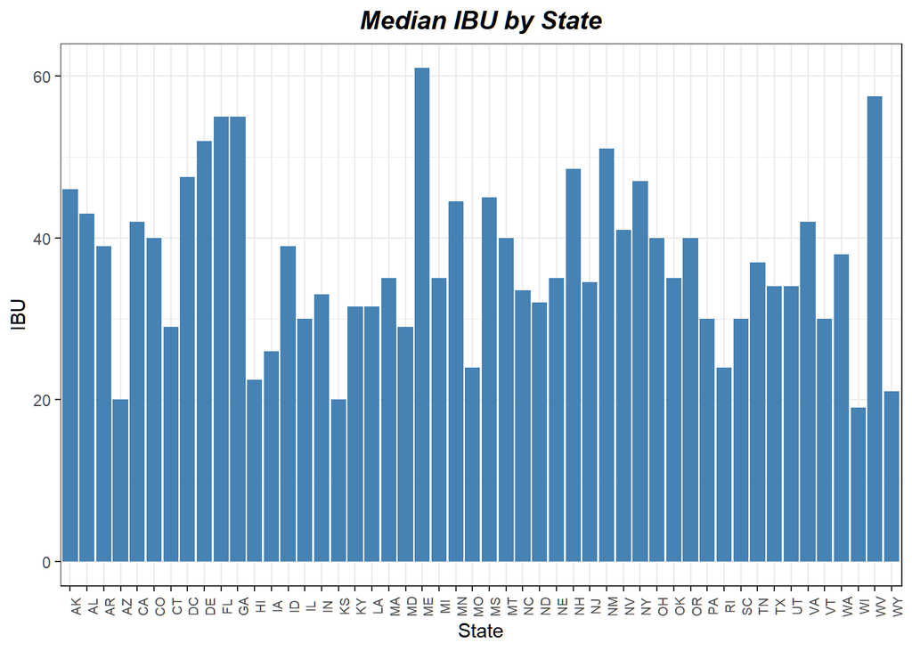

```r
ggplot(data=Bitter, aes(x=State, y=Median_IBU)) +
  geom_bar(stat="identity", fill="steelblue")+
  theme_bw() +
  scale_color_economist()+
  theme(axis.text.x=element_text(size=7, angle=90),plot.title = element_text(size=14,hjust = 0.5, face="bold.italic"))+ ggtitle("Median IBU by State") + labs(x="State",y="IBU")
```

#5- Which state has the maximum alcoholic (ABV) beer? Which state has the most bitter (IBU) beer?

####By using which.max function and indexing we found ME has maximum ABV and IBU

```r
# finding state which has has the maximum alcoholic (ABV) beer
Max_ABV <- Alc[which.max(Alc$Median_ABV),]
Max_ABV
```

```
## # A tibble: 1 x 2
##   State Median_ABV
##   <chr>      <dbl>
## 1 ME         0.067
```

```r
# finding state which has has the maximum alcoholic (IBU) beer
Max_IBU <- Bitter[which.max(Bitter$Median_IBU),]
Max_IBU
```

```
## # A tibble: 1 x 2
##   State Median_IBU
##   <chr>      <dbl>
## 1 ME            61
```

# 6- Summary statistics for the ABV variable

####To do this, we apply the function summary() to the variable ABV (alcohol content of our data set ‘BrewPub’), which returns descriptive statistics of ABV such as the minimum value (smallest value of ABV), the first quartile, the median, the mean, the thrid quartile, and the maximum (largest value of ABV).

```r
# summary statistics for the ABV variable
summary(BrewPub$ABV)
```

```
##    Min. 1st Qu.  Median    Mean 3rd Qu.    Max.    NA's
## 0.00100 0.05000 0.05600 0.05977 0.06700 0.12800      62
```

# 7- Is there an apparent relationship between the bitterness of the beer and its alcoholic content?

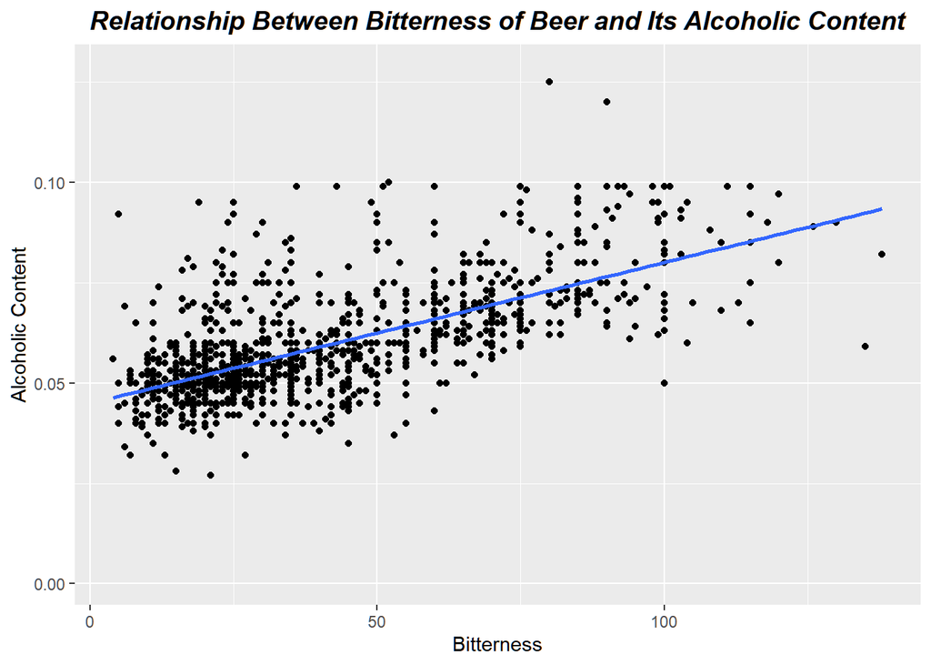

```r
# drawing a Scatter plot Bitterness of Beer vs Alcholic content
ggplot(BrewPub, aes(x=BrewPub$IBU, y=BrewPub$ABV)) + geom_point() + geom_smooth(method=lm, se=FALSE) + theme(plot.title = element_text(size=14,hjust= 0.5, face="bold.italic")) + ggtitle("Relationship Between Bitterness of Beer and Its Alcoholic Content") +
  labs(x="Bitterness",y="Alcoholic Content")
```

# Explanatory Data Analysis

```r
# Creating Region Col
StateAbb <- as.data.frame(state.abb) # usnig stat.abb dataset
StateRegion <- as.data.frame(state.region) # using state.region dataser
# Combinde 2 datasets
State <- cbind(StateAbb,StateRegion)
names(State) <- c("State" , "Region")
# Merge State by BrewPub
BrewRegion <- merge(BrewPub,State, by="State")
```

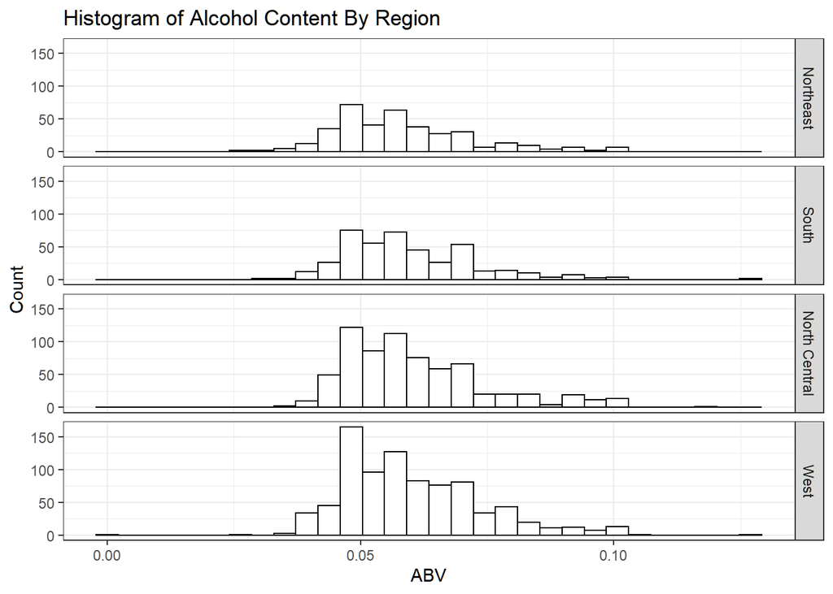

```r
# Histogram of ABV
ABV_Hist <- ggplot(BrewRegion,aes(x=ABV)) + geom_histogram(colour="black", fill="white") +theme(axis.text.x=element_text(size=7), plot.title = element_text(size=14,hjust = 0.5, face="bold.italic")) + theme_bw() + ggtitle("Histogram of Alcohol Content By Region") + labs(x="ABV",y="Count") +  facet_grid(Region ~ .)
ABV_Hist
```

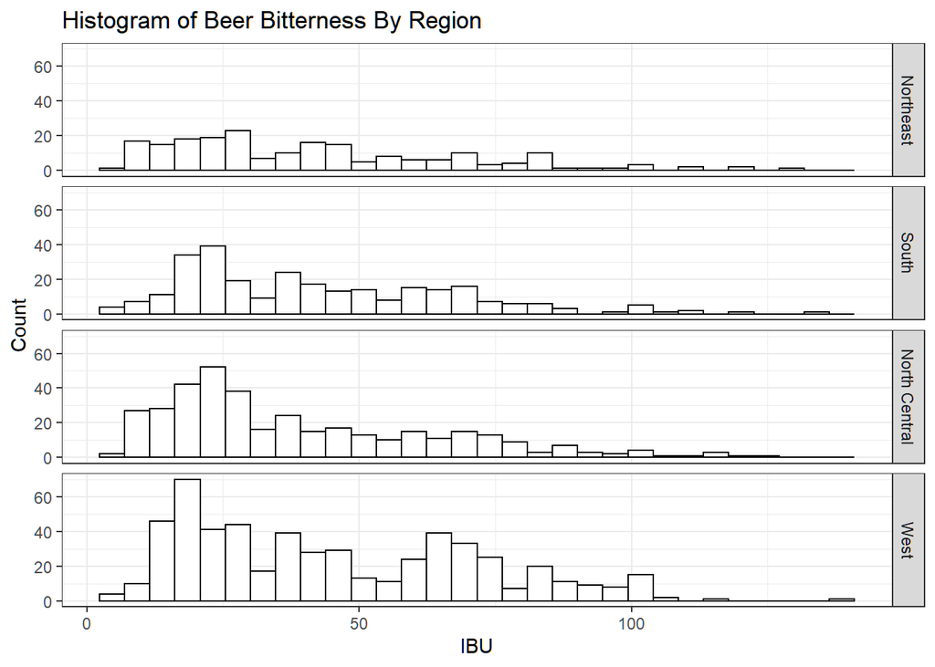

```r
# Histogram of IBU
IBU_Hist <- ggplot(BrewRegion,aes(x=IBU)) + geom_histogram(colour="black", fill="white") +theme(axis.text.x=element_text(size=7), plot.title = element_text(size=14,hjust = 0.5, face="bold.italic")) + theme_bw() + ggtitle("Histogram of Beer Bitterness By Region") + labs(x="IBU",y="Count") + facet_grid(Region ~ .)
IBU_Hist
```

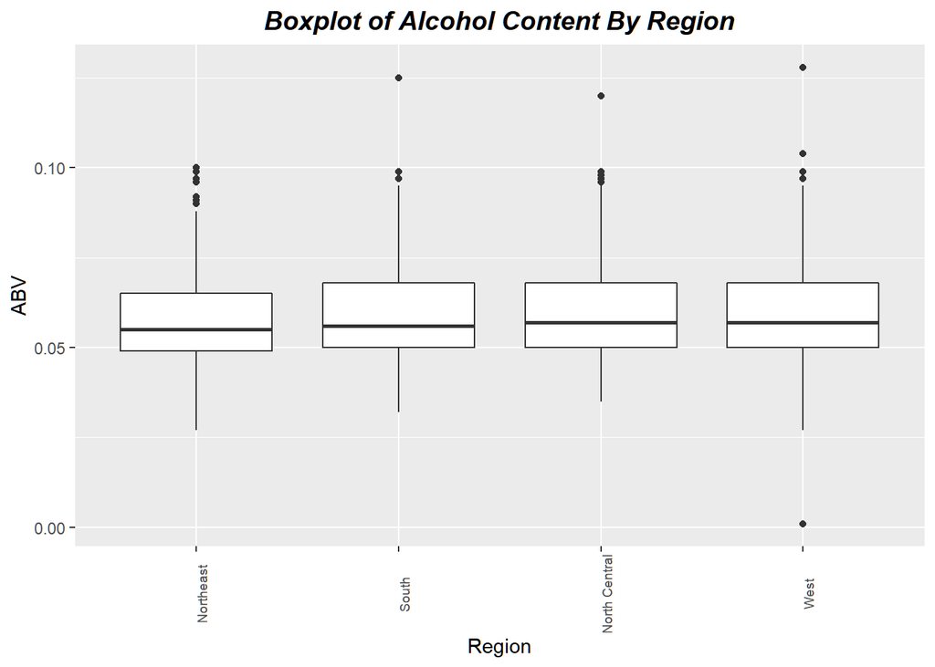

```r
# Boxplot of Alcohol Content By Region
Alch<-ggplot((BrewRegion), aes(x = Region, y = ABV)) + geom_boxplot() + theme(axis.text.x=element_text(size=7, angle=90), plot.title = element_text(size=14,hjust = 0.5, face="bold.italic"))+ ggtitle("Boxplot of Alcohol Content By Region") + labs(x="Region",y="ABV")
Alch
```

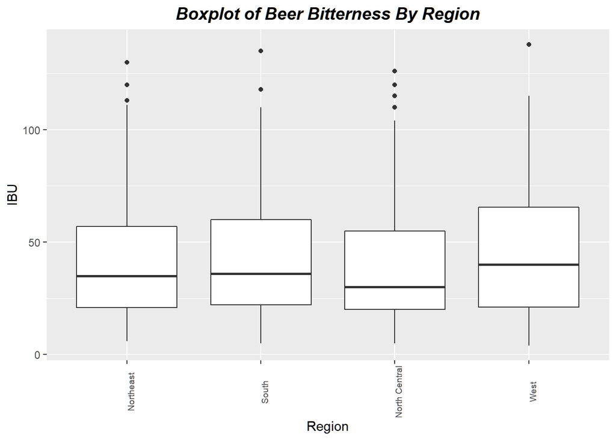

```r
# Boxplot of Beer Bitterness By Region
Bitt<- ggplot((BrewRegion), aes(x = Region, y = IBU)) + geom_boxplot() + theme(axis.text.x=element_text(size=7, angle=90), plot.title = element_text(size=14,hjust = 0.5, face="bold.italic"))+ ggtitle("Boxplot of Beer Bitterness By Region") + labs(x="Region",y="IBU")
Bitt
```

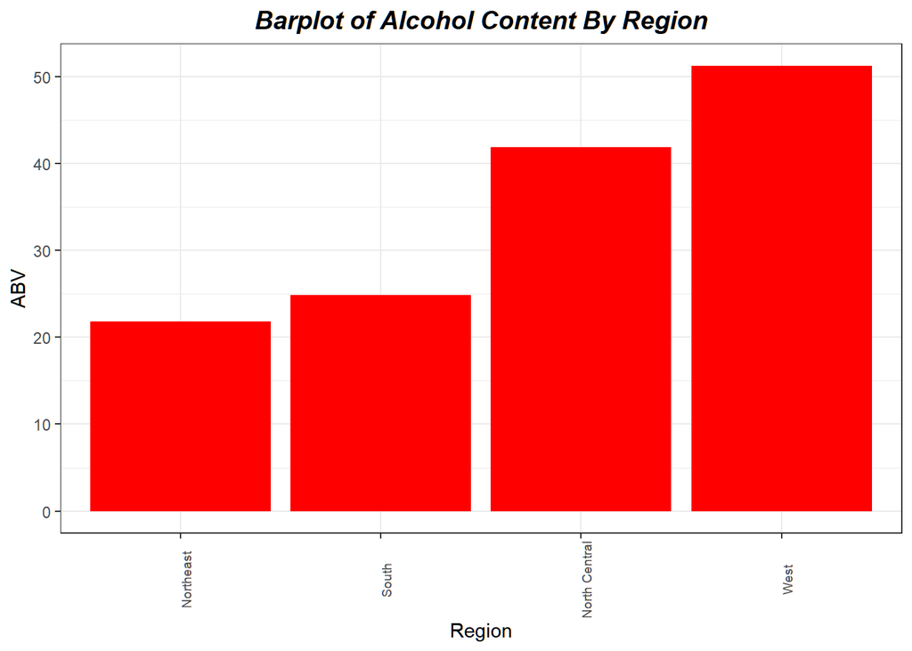

```r
# ABV per Region Bar Plot
ggplot(BrewRegion, aes(x=Region, y=ABV)) +
  geom_bar(stat="identity", fill="red")+
  theme_bw() +
  scale_color_economist()+
  theme(axis.text.x=element_text(size=rel(0.8), angle=90),plot.title = element_text(size=14,hjust = 0.5, face="bold.italic")) +
  ggtitle("Barplot of Alcohol Content By Region") +
  labs(x="Region",y="ABV")
```

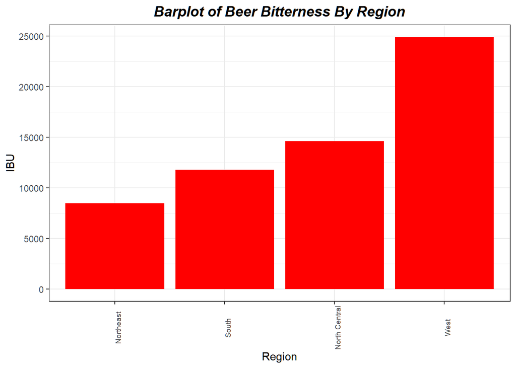

```r
# IBU per Region Bar plot
ggplot(BrewRegion, aes(x=Region, y=IBU)) +
  geom_bar(stat="identity", fill="red")+
  theme_bw() +
  scale_color_economist()+
  theme(axis.text.x=element_text(size=rel(0.8), angle=90),plot.title = element_text(size=14,hjust = 0.5, face="bold.italic")) +
  ggtitle("Barplot of Beer Bitterness By Region") +
  labs(x="Region",y="IBU")
```

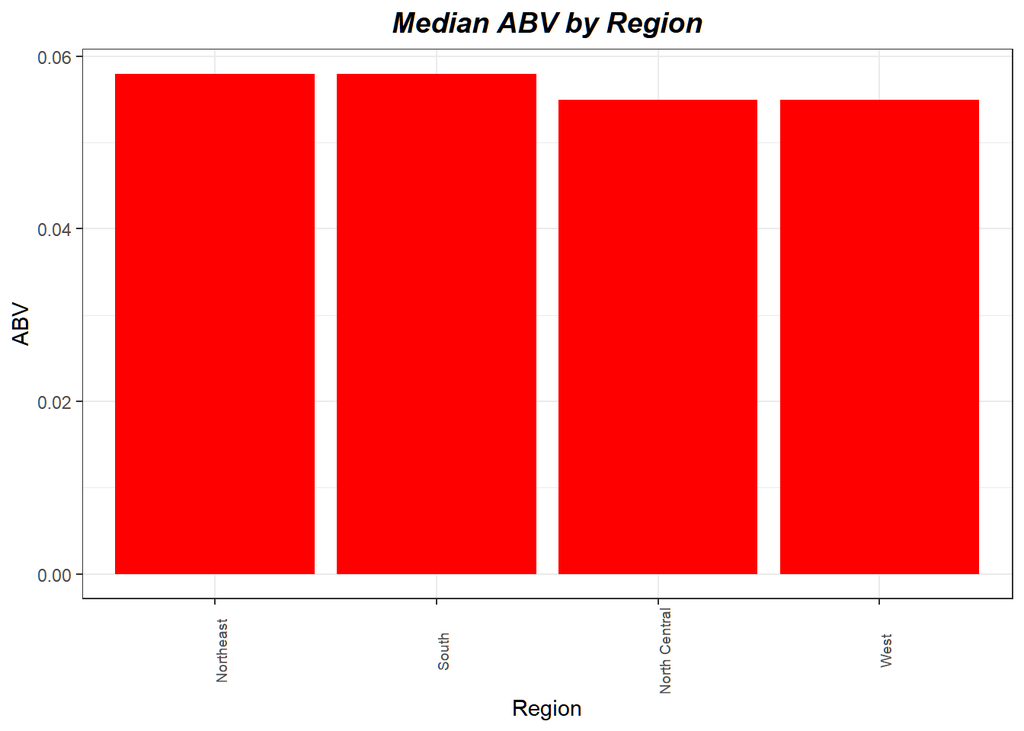

```r
#  Plot a bar chart to compare Median of ABV by Region

BrewRegion %>%   na.omit() %>%
group_by(Region) %>%
summarise_each(funs(median), Median_ABV = ABV) %>% ggplot(aes(x=Region, y=sort(Median_ABV,decreasing = TRUE))) +
  geom_bar(stat="identity", fill="red")+
  theme_bw() +
  scale_color_economist()+
  theme(axis.text.x=element_text(size=rel(0.8), angle=90),plot.title = element_text(size=14,hjust = 0.5, face="bold.italic")) +
  ggtitle("Median ABV by Region") +
  labs(x="Region",y="ABV")
```

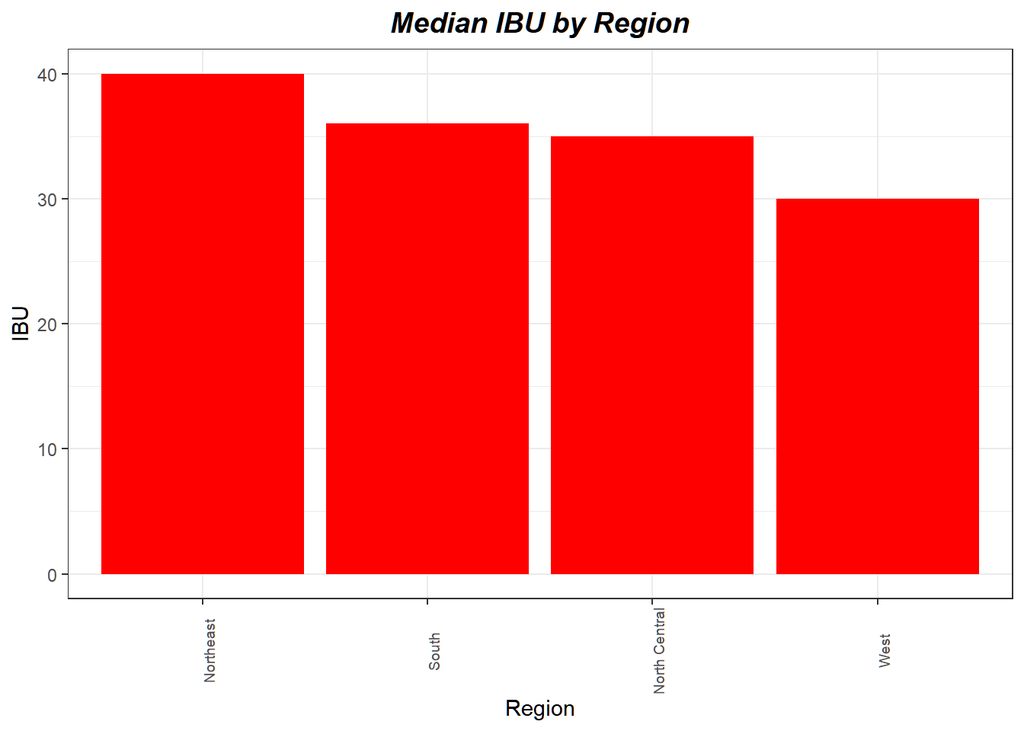

```r
#  Plot a bar chart to compare Median of IBU by Region

BrewRegion %>%   na.omit() %>%
group_by(Region) %>%
summarise_each(funs(median), Median_IBU = IBU) %>% ggplot(aes(x=Region, y=sort(Median_IBU,decreasing = TRUE))) +
  geom_bar(stat="identity", fill="red")+
  theme_bw() +
  scale_color_economist()+
  theme(axis.text.x=element_text(size=rel(0.8), angle=90),plot.title = element_text(size=14,hjust = 0.5, face="bold.italic")) +
  ggtitle("Median IBU by Region") +
  labs(x="Region",y="IBU")
```

#Analysis Of Variance

```r
# Compute the analysis of variance for ABV mean
BeerABV.aov <- aov(ABV ~ Region, data = BrewRegion)
# Summary of the analysis
summary(BeerABV.aov)
```

```
##               Df Sum Sq   Mean Sq F value Pr(>F)
## Region         3 0.0017 0.0005511   3.015 0.0289 *
## Residuals   2336 0.4270 0.0001828
## ---
## Signif. codes:  0 '***' 0.001 '**' 0.01 '*' 0.05 '.' 0.1 ' ' 1
## 62 observations deleted due to missingness
```

```r
# There is no evidence showing that at confidence level of 0.05 the mean of ABV in each region are the same (P-Value = 0.02)


# Compute the analysis of variance for IBU mean
BeerIBU.aov <- aov(IBU ~ Region, data = BrewRegion)
# Summary of the analysis
summary(BeerIBU.aov)
```

```
##               Df Sum Sq Mean Sq F value  Pr(>F)
## Region         3   9220  3073.4   4.626 0.00317 **
## Residuals   1397 928142   664.4
## ---
## Signif. codes:  0 '***' 0.001 '**' 0.01 '*' 0.05 '.' 0.1 ' ' 1
## 1001 observations deleted due to missingness
```

### There is no evidence showing that at confidence level of 0.05 the mean of IBU in each region are the same (P-Value = 0.0031)